# PREGUNTA 1

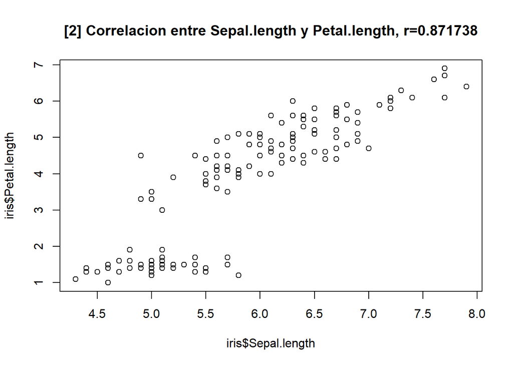

```r
#Correlacion entre Sepal.length y Petal.length
plot(iris$Sepal.length,iris$Petal.length,main="[2] Correlacion entre Sepal.length y Petal.length, r=0.871738")
```

Se graficara las relaciones de correlacion minimas las cuales son:

- [4] Sepal.width - Petal.length
- [5] Sepal.width - Petal.width

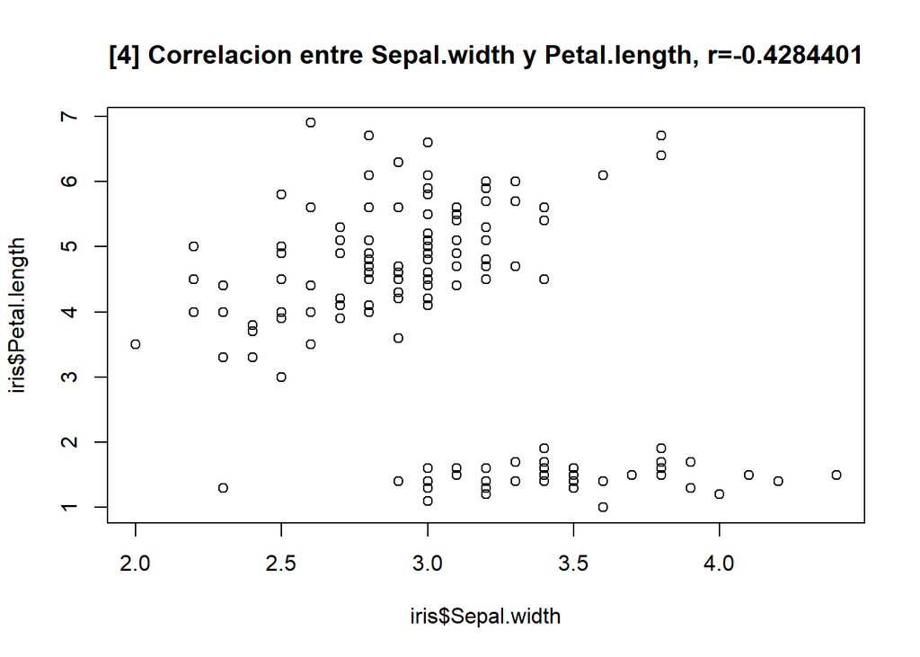

```r
#Correlacion entre Sepal.width y Petal.length
plot(iris$Sepal.width,iris$Petal.length,main="[4] Correlacion entre Sepal.width y Petal.length, r=-0.4284401")
```

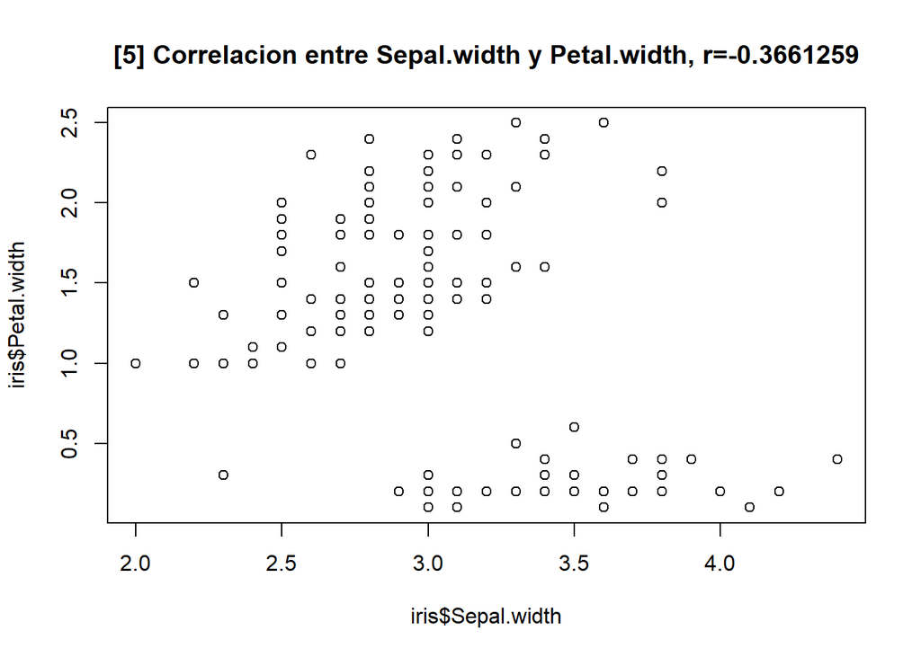

```r
#Correlacion entre Sepal.width y Petal.width
plot(iris$Sepal.width,iris$Petal.width,main="[5] Correlacion entre Sepal.width y Petal.width, r=-0.3661259")
```

**Comentario**

Se observa que la correlacion mas alta corresponde entre la variable Petal.length y Petal.width, la cual es $r=.9628654$, esto nos indica que si una variable aumenta la otra variable aunmenta tambien, a esta correlacion se le denomina correlacion positiva fuerte fuerte. La correlacion mas baja se da entre las variables Sepal.width y Petal.length, la cual es $r=-0.4284401$, esto nos indica que que si una variable aumenta la otra disminuye, a esta correlacion se la denomina correlacion negativa debil.

**PARA LA DATA DECATHLON**

De la matrix de correlacion de las variables Decathlon, vemos que las variable con mayor correlacion son:

- Shot.put - Discus con r=0.6157681
- X100m - X110m.hurdle con r=0.579888931

De la matrix de correlacion vemos que las variable con menor correlacion son:

- X400m - Long.jump con r=-0.60206262
- Long.jump - X100m con r=-0.59867767

```r
#Calculo de correlacion de toda la tabla, cruzando variables
cor(deca[,1:10])
```

```
##                    X100m   Long.jump    Shot.put   High.jump        X400m
## X100m         1.00000000 -0.59867767 -0.35648227 -0.24625292  0.520298155
## Long.jump    -0.59867767  1.00000000  0.18330436  0.29464444 -0.602062618
## Shot.put     -0.35648227  0.18330436  1.00000000  0.48921153 -0.138432919
## High.jump    -0.24625292  0.29464444  0.48921153  1.00000000 -0.187956928
## X400m         0.52029815 -0.60206262 -0.13843292 -0.18795693  1.000000000
## X110m.hurdle  0.57988893 -0.50541009 -0.25161571 -0.28328909  0.547987756
## Discus       -0.22170757  0.19431009  0.61576810  0.36921834 -0.117879365
## Pole.vault   -0.08253683  0.20401411  0.06118185 -0.15618074 -0.079292469
## Javeline     -0.15774645  0.11975893  0.37495551  0.17188009  0.004232096
## X1500m       -0.06054645 -0.03368613  0.11580306 -0.04490252  0.408106432
##              X110m.hurdle     Discus   Pole.vault     Javeline      X1500m
## X100m         0.579888931 -0.2217076 -0.082536834 -0.157746452 -0.06054645
## Long.jump    -0.505410086  0.1943101  0.204014112  0.119758933 -0.03368613
## Shot.put     -0.251615714  0.6157681  0.061181853  0.374955509  0.11580306
## High.jump    -0.283289090  0.3692183 -0.156180742  0.171880092 -0.04490252
## X400m         0.547987756 -0.1178794 -0.079292469  0.004232096  0.40810643
## X110m.hurdle  1.000000000 -0.3262010 -0.002703885  0.008743251  0.03754024
## Discus       -0.326200961  1.0000000 -0.150072400  0.157889799  0.25817510
## Pole.vault   -0.002703885 -0.1500724  1.000000000 -0.030000603  0.24744778
## Javeline      0.008743251  0.1578898 -0.030000603  1.000000000 -0.18039313
## X1500m        0.037540240  0.2581751  0.247447780 -0.180393128  1.00000000
```

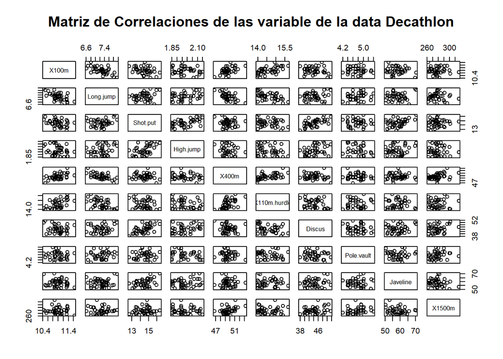

```r
#Matriz de Correlaciones total
plot(deca[,1:10], main="Matriz de Correlaciones de las variable de la data Decathlon")
```

Se graficara primero las relaciones de correlacion maximas las cuales son:

- [1] Shot.put - Discus con r=0.6157681
- [2] X100m - X110m.hurdle con r=0.579888931

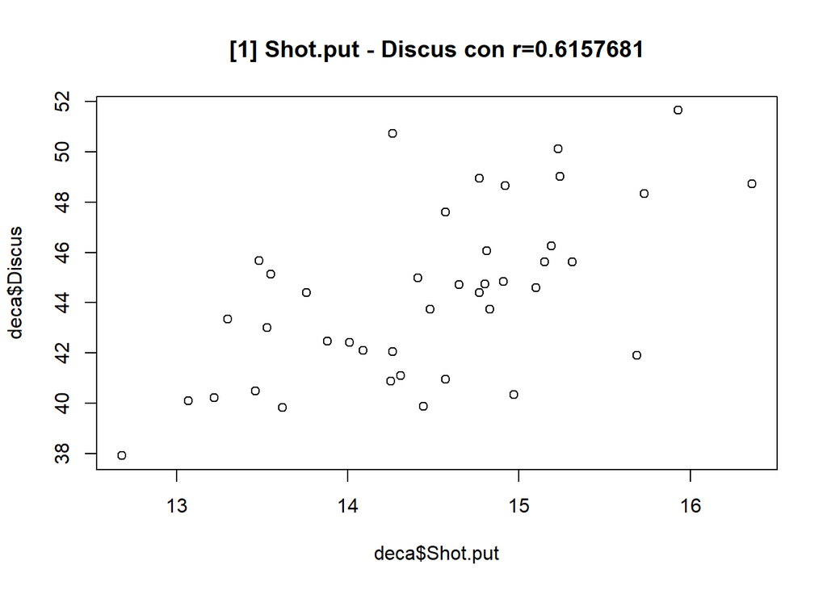

```r
#Correlacion entre Shot.put y Discus
plot(deca$Shot.put,deca$Discus,main="[1] Shot.put - Discus con r=0.6157681")
```